# Tugas Pertemuan 5

Yasmin Azimah

2023-09-23

```r
library(ggplot2)
library(tsibble)
library(tseries)
library(MASS)
```

### Input Data

```r
data <- rio::import("https://raw.githubusercontent.com/yasminazimah/MPDW/main/data/Data1.csv")
data <- data$Jumlah_Kematian
data.ts <- ts(data)
```

### Plot *Time Series*

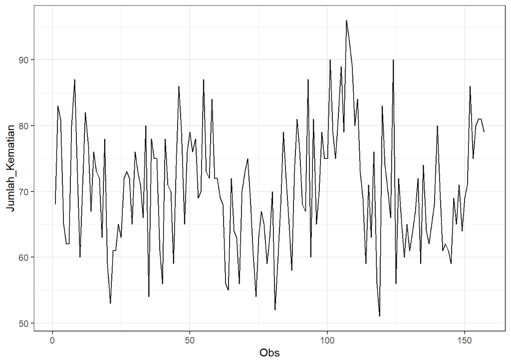

```r
plot_data.ts <- data.ts |> as_tsibble() |>
  ggplot(aes(x = index, y = value)) + geom_line() + theme_bw() +
  xlab("Obs") + ylab("Jumlah_Kematian")
plot_data.ts
```

```r
mean(data.ts)
```

```
## [1] 70.54777
```

Plot deret waktu di atas menunjukkan bahwa data stasioner dalam rataan, ditandai dengan data yang menyebar di sekitar nilai tengahnya (70.54777) dan stasioner dalam ragam, ditandai dengan lebar pita yang cenderung sama.

### Plot ACF

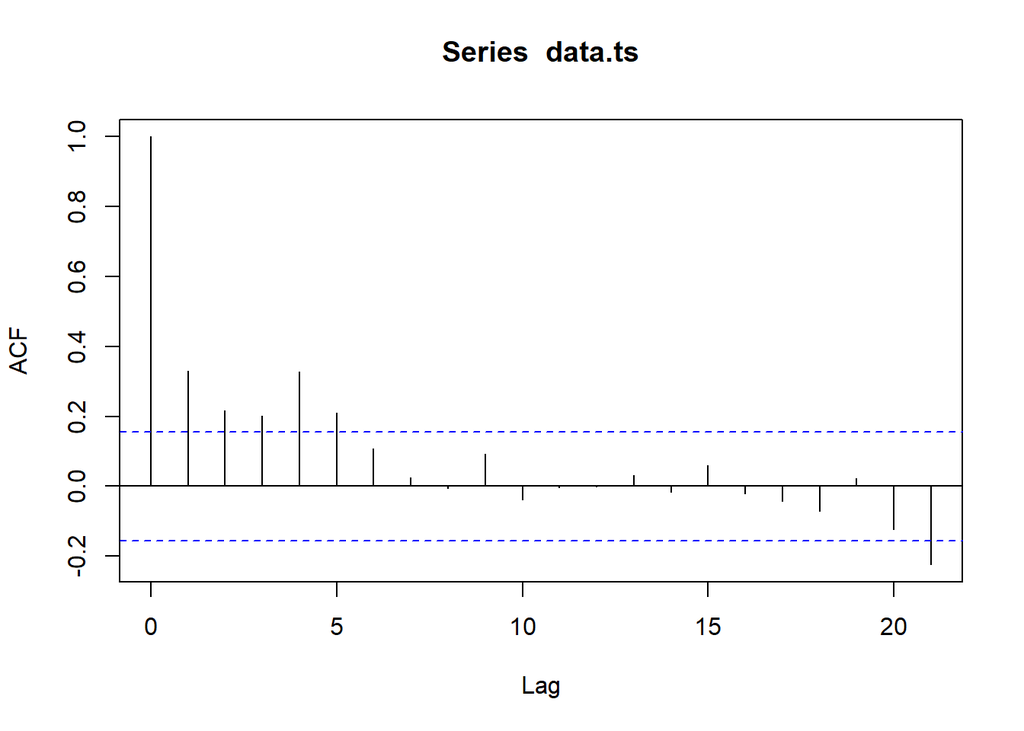

```r
acf(data.ts)
```

Berdasarkan plot ACF, terlihat bahwa plot ACF pada data tersebut cenderung *tails off* dan membentuk gelombang sinus yang menandakan data stasioner dalam rataan.

### Uji ADF

```r
tseries::adf.test(data.ts)
```

```
##
##  Augmented Dickey-Fuller Test
##
## data:  data.ts
## Dickey-Fuller = -2.9932, Lag order = 5, p-value = 0.1622
## alternative hypothesis: stationary
```

$H_0$ : Data tidak stasioner dalam rataan

$H_1$ : Data stasioner dalam rataan

Berdasarkan uji ADF tersebut, didapat *p-value* sebesar 0.1622 yang lebih besar dari taraf nyata 5% sehingga tak tolak $H_0$ dan menandakan bahwa data tidak stasioner dalam rataan. Hal ini tidak sesuai dengan hasil eksplorasi menggunakan plot time series dan plot ACF.

### Plot Box-Cox

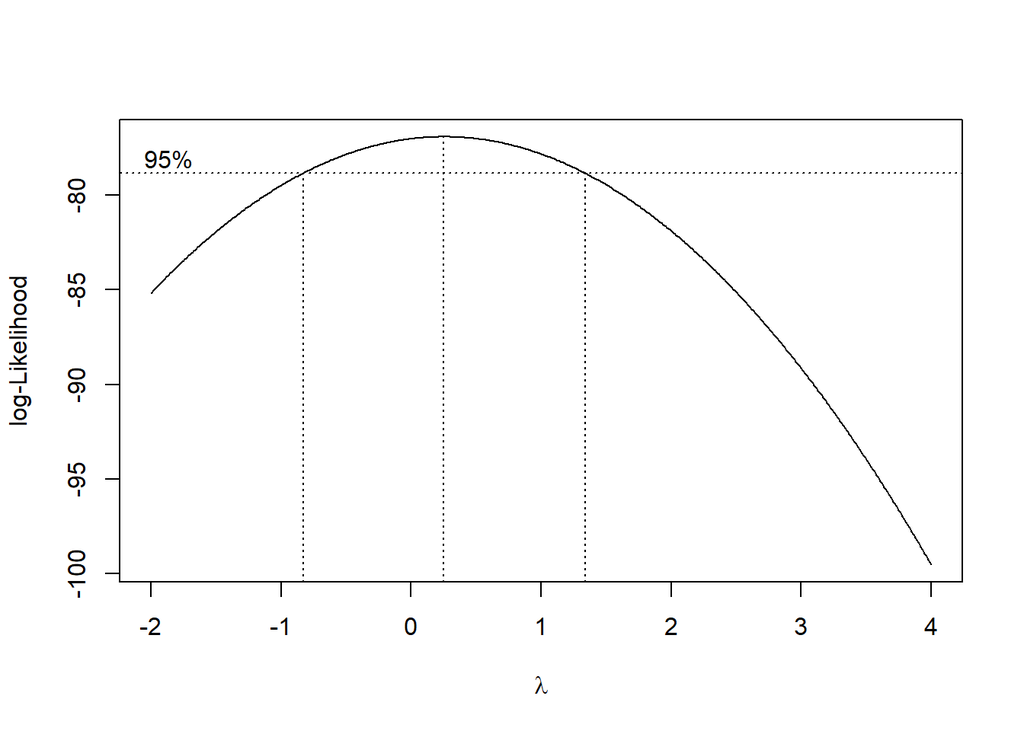

```r
index <- seq(1:157)
bc = boxcox(data.ts~index, lambda = seq(-2,4,by=0.01))
```

```r
#Nilai Rounded Lambda
lambda <- bc$x[which.max(bc$y)]
lambda
```

```
## [1] 0.25
```

```r
#SK
bc$x[bc$y > max(bc$y) - 1/2 * qchisq(.95,1)]
```

```
##   [1] -0.83 -0.82 -0.81 -0.80 -0.79 -0.78 -0.77 -0.76 -0.75 -0.74 -0.73 -0.72
##  [13] -0.71 -0.70 -0.69 -0.68 -0.67 -0.66 -0.65 -0.64 -0.63 -0.62 -0.61 -0.60
##  [25] -0.59 -0.58 -0.57 -0.56 -0.55 -0.54 -0.53 -0.52 -0.51 -0.50 -0.49 -0.48
##  [37] -0.47 -0.46 -0.45 -0.44 -0.43 -0.42 -0.41 -0.40 -0.39 -0.38 -0.37 -0.36
##  [49] -0.35 -0.34 -0.33 -0.32 -0.31 -0.30 -0.29 -0.28 -0.27 -0.26 -0.25 -0.24
##  [61] -0.23 -0.22 -0.21 -0.20 -0.19 -0.18 -0.17 -0.16 -0.15 -0.14 -0.13 -0.12
##  [73] -0.11 -0.10 -0.09 -0.08 -0.07 -0.06 -0.05 -0.04 -0.03 -0.02 -0.01  0.00
##  [85]  0.01  0.02  0.03  0.04  0.05  0.06  0.07  0.08  0.09  0.10  0.11  0.12
##  [97]  0.13  0.14  0.15  0.16  0.17  0.18  0.19  0.20  0.21  0.22  0.23  0.24
## [109]  0.25  0.26  0.27  0.28  0.29  0.30  0.31  0.32  0.33  0.34  0.35  0.36
## [121]  0.37  0.38  0.39  0.40  0.41  0.42  0.43  0.44  0.45  0.46  0.47  0.48
## [133]  0.49  0.50  0.51  0.52  0.53  0.54  0.55  0.56  0.57  0.58  0.59  0.60
## [145]  0.61  0.62  0.63  0.64  0.65  0.66  0.67  0.68  0.69  0.70  0.71  0.72
## [157]  0.73  0.74  0.75  0.76  0.77  0.78  0.79  0.80  0.81  0.82  0.83  0.84
## [169]  0.85  0.86  0.87  0.88  0.89  0.90  0.91  0.92  0.93  0.94  0.95  0.96
## [181]  0.97  0.98  0.99  1.00  1.01  1.02  1.03  1.04  1.05  1.06  1.07  1.08
## [193]  1.09  1.10  1.11  1.12  1.13  1.14  1.15  1.16  1.17  1.18  1.19  1.20
## [205]  1.21  1.22  1.23  1.24  1.25  1.26  1.27  1.28  1.29  1.30  1.31  1.32
## [217]  1.33
```

Gambar di atas menunjukkan nilai *rounded value* ($\lambda$) optimum sebesar **0,25** dan pada selang kepercayaan 95% nilai memiliki batas bawah **-0,83** dan batas atas **1,33**. Selang tersebut memuat nilai satu sehingga dapat dikatakan bahwa data bangkitan stasioner dalam ragam.

### Partisi Data

#### Bagian 1

```r
dt_1 <- data.ts[1:63] |> ts()
mean(dt_1)
```

```
## [1] 70.98413
```

```r
var(dt_1)
```

```
## [1] 68.3062
```

#### Plot Time Series

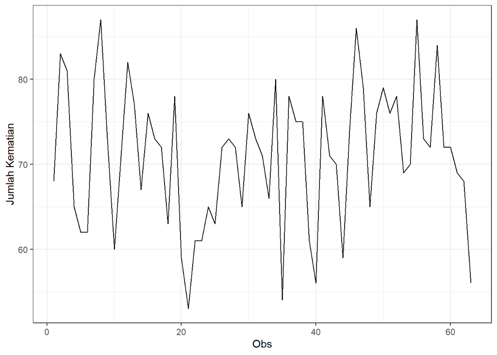

```r
dt_1 |> as_tsibble() |>
  ggplot(aes(x = index, y = value)) +
  geom_line() + theme_bw() +
  xlab("Obs") + ylab("Jumlah Kematian")
```

```r
mean(dt_1)
```

```
## [1] 70.98413
```

Plot deret waktu di atas menunjukkan bahwa data stasioner dalam rataan, ditandai dengan data yang menyebar di sekitar nilai tengahnya (70.98413) dan stasioner dalam ragam, ditandai dengan lebar pita yang cenderung sama.

#### Plot ACF

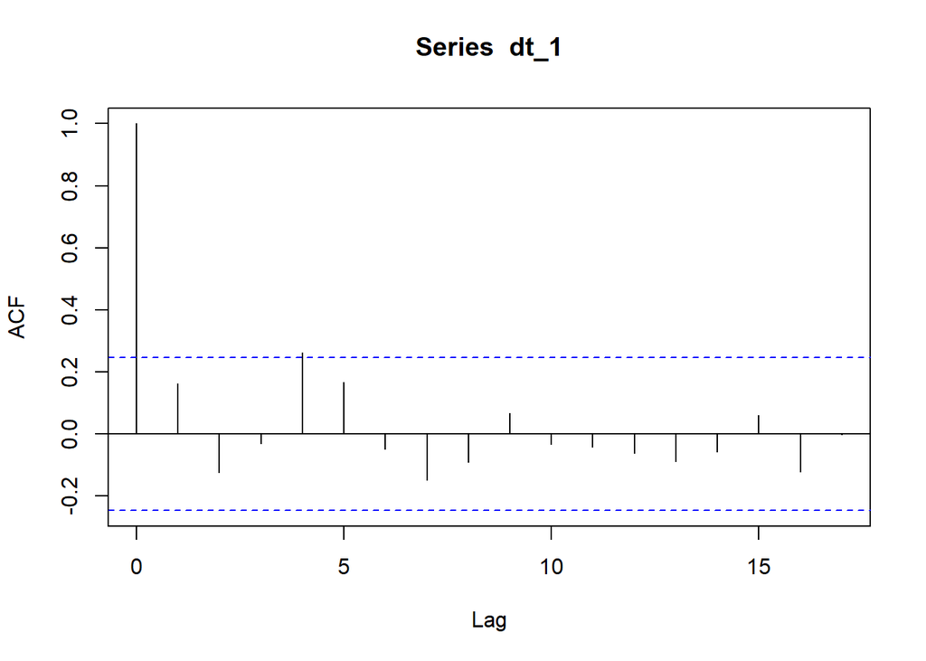

```r
acf(dt_1)
```

Berdasarkan plot ACF, terlihat bahwa plot ACF pada data tersebut cenderung *tails off* dan membentuk gelombang sinus yang menandakan data stasioner dalam rataan.

#### Uji ADF

```r
tseries::adf.test(dt_1)
```

```
##
##  Augmented Dickey-Fuller Test
##
## data:  dt_1
## Dickey-Fuller = -2.6757, Lag order = 3, p-value = 0.3013
## alternative hypothesis: stationary
```

$H_0$ : Data tidak stasioner dalam rataan

$H_1$ : Data stasioner dalam rataan

Berdasarkan uji ADF tersebut, didapat *p-value* sebesar 0.3013 yang lebih besar dari taraf nyata 5% sehingga tak tolak $H_0$ dan menandakan bahwa data tidak stasioner dalam rataan. Hal ini tidak sesuai dengan hasil eksplorasi menggunakan plot time series dan plot ACF.

#### Plot Boxcox

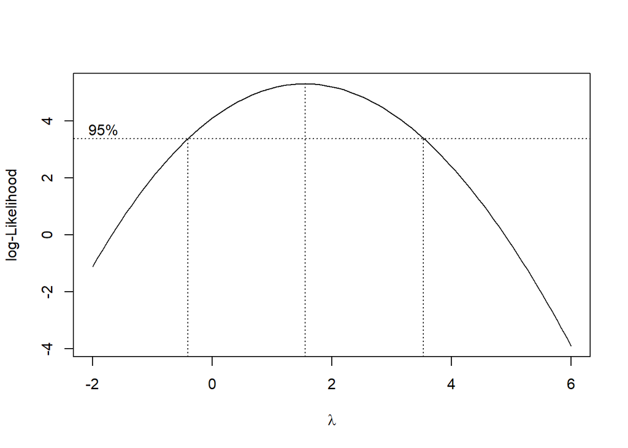

```r
index <- seq(1:63)
bc = boxcox(dt_1~index, lambda = seq(-2,6,by=1))
```

```r
#Nilai Rounded Lambda
lambda <- bc$x[which.max(bc$y)]
lambda
```

[output not shown]

```r
#SK
bc$x[bc$y > max(bc$y) - 1/2 * qchisq(.95,1)]
```

[output not shown]

#### Bagian 2

```r
dt_2 <- data.ts[64:157] |> ts()
mean(dt_2)
```

```
## [1] 70.25532
```

```r
var(dt_2)
```

```
## [1] 96.08465
```

#### Plot Time Series

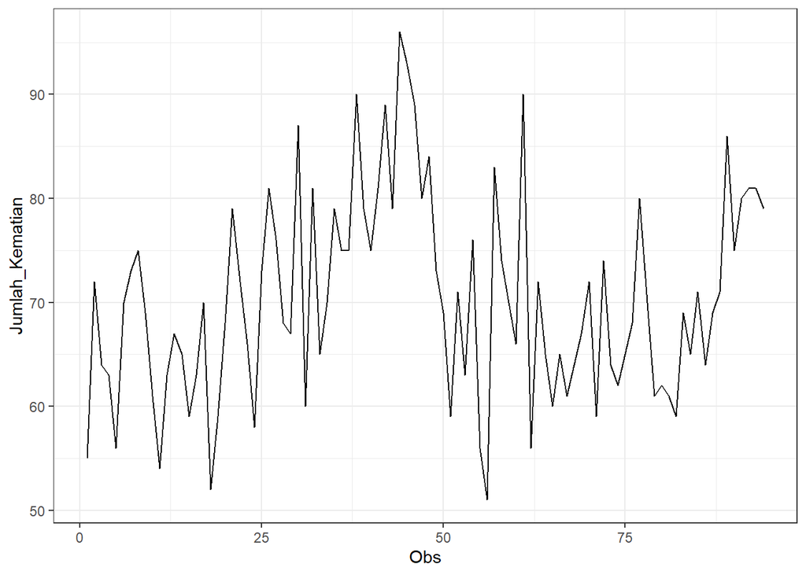

```r
dt_2 |> as_tsibble() |>
  ggplot(aes(x = index, y = value)) +
  geom_line() + theme_bw() +
  xlab("Obs") + ylab("Jumlah_Kematian")
```

```r
mean(dt_2)
```

```
## [1] 70.25532
```

Plot deret waktu di atas menunjukkan bahwa data stasioner dalam rataan, ditandai dengan data yang menyebar di sekitar nilai tengahnya (70.25532) dan stasioner dalam ragam, ditandai dengan lebar pita yang cenderung sama.

#### Plot ACF

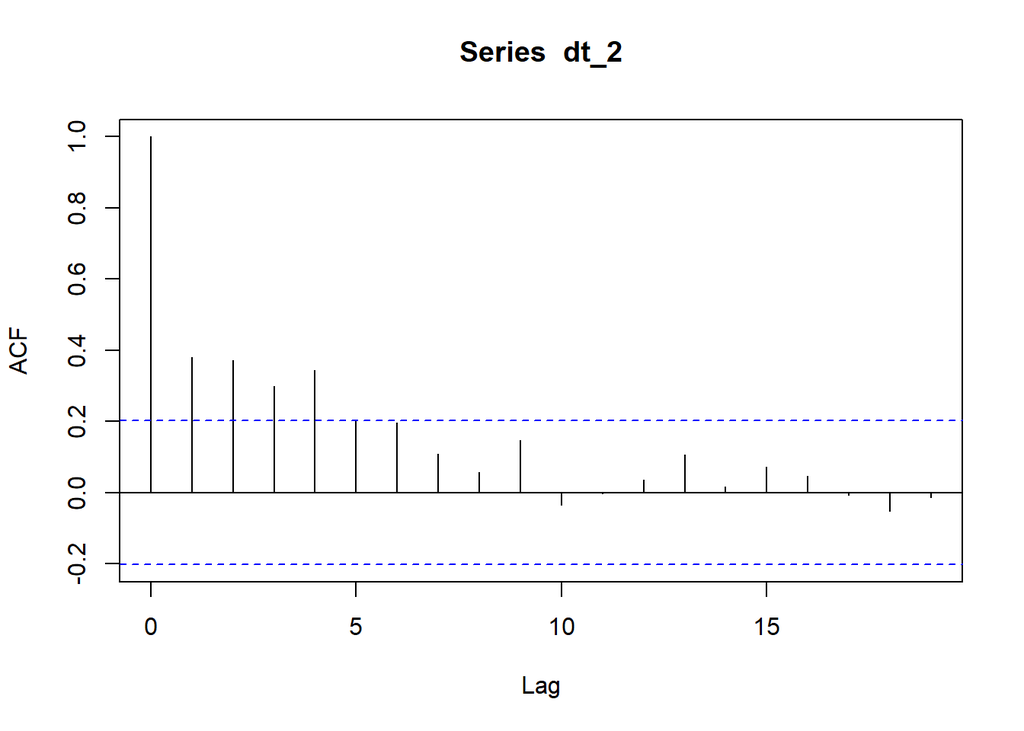

```r
acf(dt_2)
```

Berdasarkan plot ACF, terlihat bahwa plot ACF pada data tersebut cenderung *tails off* dan membentuk gelombang sinus yang menandakan data stasioner dalam rataan.

#### Uji ADF

```r
adf.test(dt_2)
```

```
##
##  Augmented Dickey-Fuller Test
##
## data:  dt_2
## Dickey-Fuller = -2.3904, Lag order = 4, p-value = 0.4152
## alternative hypothesis: stationary
```

$H_0$ : Data tidak stasioner dalam rataan

$H_1$ : Data stasioner dalam rataan

Berdasarkan uji ADF tersebut, didapat *p-value* sebesar 0.4152 yang lebih besar dari taraf nyata 5% sehingga tak tolak $H_0$ dan menandakan bahwa data tidak stasioner dalam rataan. Hal ini tidak sesuai dengan hasil eksplorasi menggunakan plot time series dan plot ACF.

#### Plot Boxcox

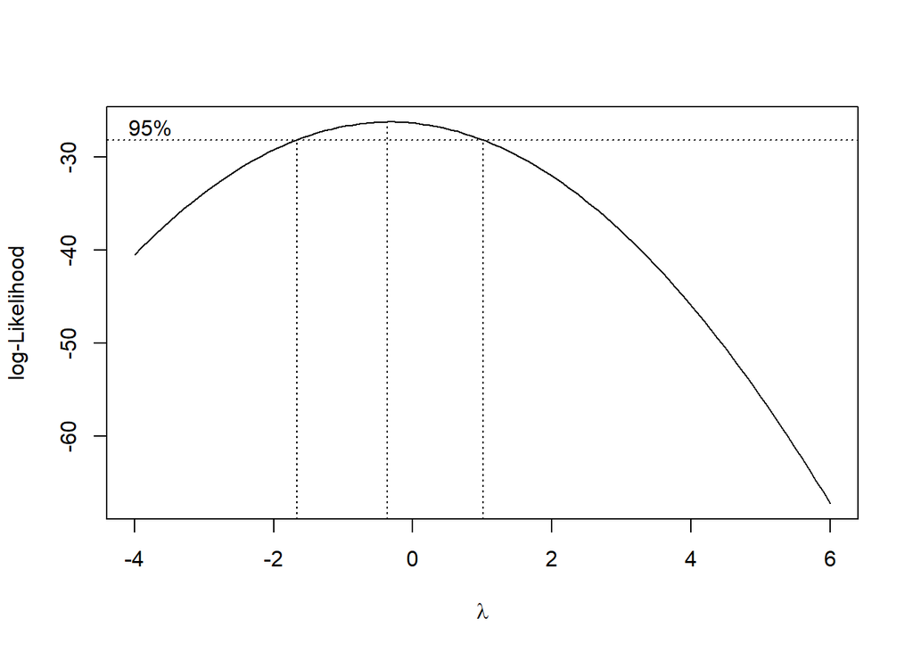

```r
index <- seq(64:157)
bc = boxcox(dt_2~index, lambda = seq(-4,6,by=1))
```

```r
#Nilai Rounded Lambda
lambda <- bc$x[which.max(bc$y)]
lambda
```

[output not shown]

```r
#SK
bc$x[bc$y > max(bc$y) - 1/2 * qchisq(.95,1)]
```

[output not shown]